# 005-exercise5_students

Johannes Schade (5564109)

Yolanda Seifert (5477060)

David Bauer (5398867)

```python
import numpy as np
import pandas as pd

from sklearn.linear_model import LinearRegression
from sklearn.preprocessing import StandardScaler
from sklearn.model_selection import train_test_split
from sklearn.metrics import r2_score, mean_squared_error
from sklearn import datasets

import tensorflow as tf
from tensorflow.keras import Input, Model, layers, losses, optimizers

from matplotlib import pyplot as plt
```

**Differential Privacy**

The goal of differential privacy is to minimize the effect, a single training sample can have of the output of a (randomized) algorithm. Therefore, perform the following tasks:

1. Load the boston housing dataset, one-hot encode the categorical features and normalize (use StandardScaler) the continuous features.
2. Split the data into train/test (80% / 20%) sets (give a seed for reproducibility, i.e. random_state=42).
3. Train a LinearRegression model (set fit_intercept=False) on the training set and compute r2_score and mean_squared_error on the test set.
4. Find the training sample with the largest prediction error. Create a mask to exclude that **sample** from the training set.
5. Fit the same LinearRegression model to the training set excluding the found **sample**. Measure the deviation of the two regression models (e.g. np.linalg.norm(w-w'), the weights w can be found in LinearRegression.coef_)
6. Add noise of varying scales to the training set, create a second training set by excluding the **sample** and train linear regression models on each. How does the utility (r2_score, mse) behave with increasing noise level? What happens to the difference between the fitted models' weights? What about the prediction error on the **sample**? Plot the r2_score, mse, prediction error on **sample** and weight difference over the noise scale.

```python
# load dataset
boston_dataset = datasets.load_boston()
X = pd.DataFrame(boston_dataset.data, columns=boston_dataset.feature_names)
Y = pd.DataFrame(boston_dataset.target, columns=['price'])

# normalize continuous features
cont_features = ['CRIM', 'ZN', 'INDUS', 'NOX', 'RM', 'AGE', 'DIS', 'TAX', 'PTRATIO', 'B', 'LSTAT']
feature_scaler = StandardScaler()
X_pp = X.copy()
X_pp[cont_features] = feature_scaler.fit_transform(X[cont_features])
X_pp.head()

# normalize targets
Y_pp = Y.copy()
target_scaler = StandardScaler()
Y_pp[['price']] = target_scaler.fit_transform(Y[['price']])

# one-hot-encode the 'RAD' feature
X_pp[['CHAS', 'RAD']] = X_pp[['CHAS', 'RAD']].astype('int32')
X_pp = pd.get_dummies(X_pp, columns=['RAD'])
X_pp.head()

# split data and target DataFrames into data train, data test, target train and target test datasets
X_train, X_test, Y_train, Y_test = train_test_split(X_pp.to_numpy(), Y_pp.to_numpy(), test_size=0.20, random_state=42)
```

[output not shown]

```python
# train regression model and find sample with largest prediction error
LR = LinearRegression(fit_intercept=False)
LR.fit(X_train, Y_train)

pred = LR.predict(X_test)

print('r2 score:', r2_score(Y_test, pred))
print('mean squared error:', mean_squared_error(Y_test, pred))

index_max_err = np.argmax([(LR.predict(X_train) - Y_train) ** 2])
print('index of sample with the largest error:', index_max_err)

# create neighboring dataset, i.e. training set without the sample with largest prediction error
mask = np.ones(X_train.shape[0], dtype=bool)
mask[index_max_err] = False

# train on that dataset the same model, measure the difference between both models' coefficients
LR2 = LinearRegression(fit_intercept = False)
LR2.fit(X_train[mask], Y_train[mask])
pred2 = LR2.predict(X_test)


print('r2 score:', r2_score(Y_test, pred2))
print('mean squared error:', mean_squared_error(Y_test, pred2))

print('coef difference', np.linalg.norm(LR.coef_-LR2.coef_))
```

```
r2 score: 0.6615687658684821
mean squared error: 0.29398925875149384
index of sample with the largest error: 126
r2 score: 0.648810290104261
mean squared error: 0.3050723221760259
coef difference 0.12460854606920675
```

```python
# train on varying noise scales, you should repeat the computation for each sigma several times and average
sigmas = np.logspace(-3,2, 100) # noise scales

n = 30

r2 = []
mse = []
pred_err = []
w_diff = []

for sigma in sigmas :
    X_noise = X_train + sigma * np.random.randn(*X_train.shape)
    #X_noise = sum([X_train + sigma * np.random.randn(*X_train.shape) for i in range(n)])/n
    r2_ = []
    mse_ = []
    pred_err_ = []
    w_diff_ = []

    for i in range(n) :
        LR.fit(X_noise, Y_train)
        LR2.fit(X_noise[mask], Y_train[mask])

        pred1 = LR.predict(X_test)
        pred2 = LR.predict(X_test)

        r2_.append(r2_score(Y_test, pred1))
        mse_.append(mean_squared_error(Y_test, pred1))
        pred_err_.append(np.absolute((LR.predict(X_noise) - Y_train)[index_max_err]))
        w_diff_.append(np.linalg.norm(LR.coef_-LR2.coef_))

    r2.append(sum(r2_)/n)
    mse.append(sum(mse_)/n)
    pred_err.append(sum(pred_err_)/n)
    w_diff.append(sum(w_diff_)/n)
```

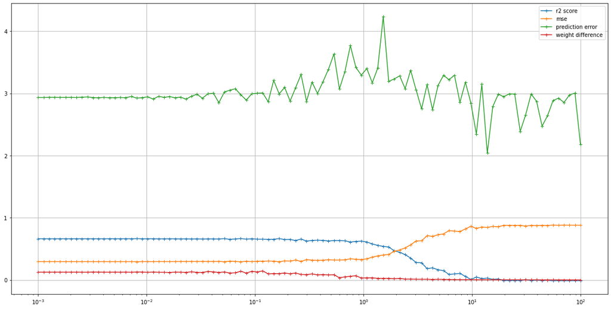

```python
# plot results
plt.figure(figsize=(20, 10))
plt.xscale('log')
plt.grid()
plt.plot(sigmas, r2, label='r2 score', marker='+')
plt.plot(sigmas, mse, label='mse', marker='+')
plt.plot(sigmas, pred_err, label='prediction error', marker='+')
plt.plot(sigmas, w_diff, label='weight difference', marker='+')

plt.legend()
plt.show()
```

**Autoencoder**

An autoencoder is a model that maps samples into a so-called latent space and then back to the original space. It consists of an encoder model X->Z and a decoder model Z->X. It is used for dimensionality reduction, representation learning and as generative model. The training objective of an autoencoder is usually a combination of reconstruction error and some regularization (on its weights and/or the latent representation).

1. Load the mnist dataset, split into 10k training samples and 1000 test samples. Take 1000 training samples for evaluation.
2. Build a linear autoencoder (encoder/decoder are linear models each). Train your autoencoder with 2D latent space Z.
3. Visualize the results as follows: For 1000 training and 1000 test samples

   a) Create a scatterplot of the latent embeddings

   b) Plot the reconstructions of 100 samples in a 10x10 grid

   c) Plot the corresponding original samples below
4. Build a non-linear autoencoder. The encoder has 2 conv layers (32/64 filters of size (3,3), strides 2), followed by a dense layer that maps to 2-dimensional latent variables. The decoder consists of a dense layer, followed by 2 conv-transpose layers (64/32, ... matching the encoder). Train the non-linear autoencoder and visualize the results as above.
5. Create synthetic samples by randomly sampling 100 points in latent space and decoding them using the linear and non-linear decoders.

```python
# load data
(x_train, y_train), (x_test, y_test) = tf.keras.datasets.mnist.load_data()

X = x_train.astype('float32').reshape((-1, 28,28,1))/255.
Xtrain, Xtest_, Ytrain, Ytest_ = train_test_split(X, y_train, train_size=10000)
Xtest, Xtest_, Ytest, Ytest_ = train_test_split(Xtest_, Ytest_, train_size=1000)

Xtrain_, _, Ytrain_, _ = train_test_split(Xtrain, Ytrain, train_size=1000)
```

```
Downloading data from https://storage.googleapis.com/tensorflow/tf-keras-datasets/mnist.npz
```

```python
# helper function to plot several samples in one image
def make_grid(X, grid_size=[10,10]):
    sh = [X.shape[1], X.shape[2]]
    G = np.zeros((sh[0]*grid_size[0], sh[1]*grid_size[1]))
    for i in range(grid_size[0]):
        for j in range(grid_size[1]):
            G[i*sh[0]:(i+1)*sh[0], j*sh[1]:(j+1)*sh[1]] = X[i*grid_size[1]+j].reshape(sh)
    return G
```

```python
# define autoencoder model
class AutoEncoder(Model):

    def __init__(self, encoder, decoder, **kwargs):
        super(AutoEncoder, self).__init__(**kwargs)
        self.encoder = encoder
        self.decoder = decoder

    def call(self, X, training=None):
        z = self.encoder(X)
        x = self.decoder(z)
        return x
```

```python
# linear models

lin_enc = tf.keras.Sequential([
            layers.Flatten(),
            layers.Dense(2)
        ])
lin_dec = tf.keras.Sequential([
            layers.Dense(28*28),
            layers.Reshape((28,28))
        ])

lin_ae = AutoEncoder(lin_enc, lin_dec)
```

```python
# train linear autoencoder
opt = optimizers.Adam(learning_rate=0.01)
loss = losses.MeanSquaredError()
lin_ae.compile(optimizer=opt, loss=loss, metrics=['mae'])

lin_ae.fit(Xtrain, Xtrain, epochs=100, shuffle=True, validation_split=0.1)
```

```
<keras.callbacks.History at 0x7f8c955c3f40>
```

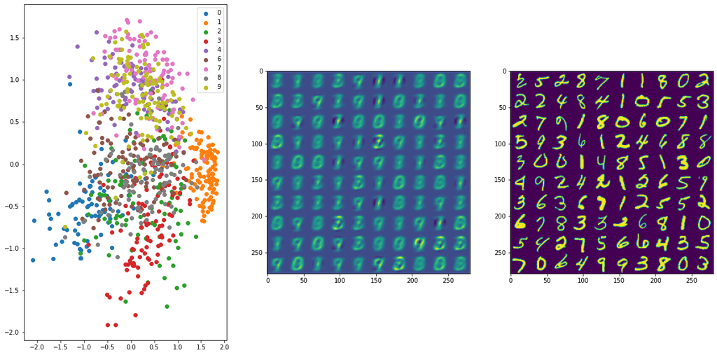

```python
# visualize latent space, reconstructions and original samples for train and test data

def visu (lin_ae) :
    encoded_imgs = lin_ae.encoder(Xtest).numpy()
    decoded_imgs = lin_ae.decoder(encoded_imgs).numpy()


    decoded_grid = make_grid(decoded_imgs)
    original_grid = make_grid(Xtest)

    fig, axes = plt.subplots(ncols=3, figsize=(20,10))
    axes[1].imshow(decoded_grid)
    axes[2].imshow(original_grid)

    for y in [0,1,2,3,4,6,7,8,9] :
        mask =  (Ytest == y)
        axes[0].scatter(encoded_imgs[mask, 0], encoded_imgs[mask,1], label=y)
    axes[0].legend()

visu(lin_ae)
```

```python
# nonlinear models

nl_enc = tf.keras.Sequential([
            layers.Conv2D(32, (3,3), activation='relu', strides=2, padding = 'same'),
            layers.Conv2D(64, (3,3), activation='relu', strides=2, padding = 'same'),
            layers.Flatten(),
            layers.Dense(2)
        ])

nl_dec = tf.keras.Sequential ([
            layers.Dense(28*28*2*2),
            layers.Reshape((7,7, 64)),
            layers.Conv2DTranspose(32, (3,3), activation='relu', strides=2, padding='same'),
            layers.Conv2DTranspose(1, (3,3), activation='relu', strides=2, padding='same')
        ])
```

```python
# train non-linear autoencoder

nl_ae = AutoEncoder(nl_enc, nl_dec)

optimizer=optimizers.Adam(learning_rate=0.001)
loss2 = losses.MeanSquaredError()

nl_ae.compile(optimizer=optimizer, loss=loss2, metrics=['mse'])

nl_ae.fit(Xtrain, Xtrain, shuffle=True, batch_size=256, epochs=100, validation_split=0.1)
```

```
<keras.callbacks.History at 0x7f8c957309a0>
```

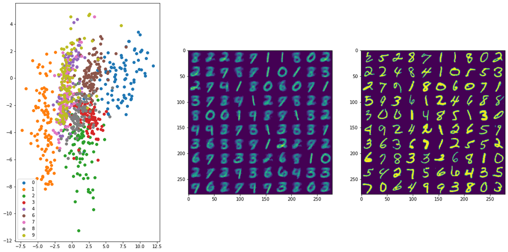

```python
# Visualization as before for non-linear model
visu(nl_ae)
```

```python
def decoder_gen (ae) :
  enc = ae.encoder(Xtest)

  samples = np.random.normal(np.mean(enc, axis=0), np.std(enc, axis=0), (100,2))
  img = ae.decoder(samples).numpy()
  plt.figure(figsize=(10,10))
  plt.imshow(make_grid(img))
```

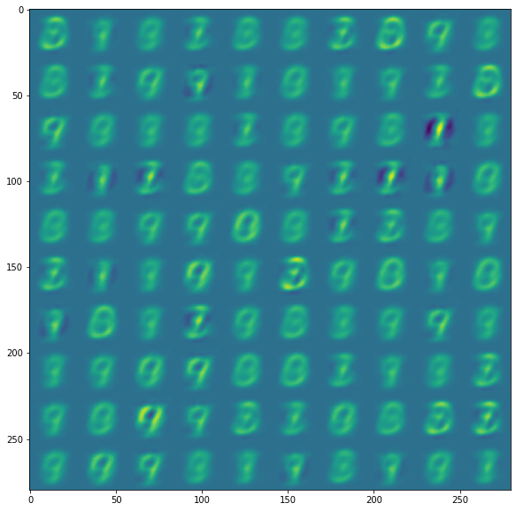

```python
# Try out linear decoder as generative model
decoder_gen(lin_ae, samples)
```

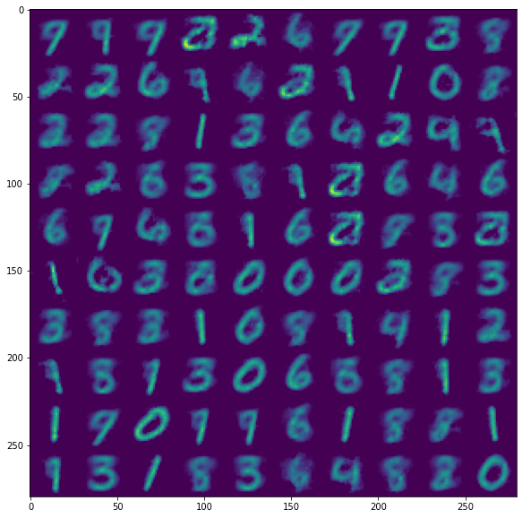

```python
# Non-linear decoder as generative model
decoder_gen(nl_ae,samples)
```